# Topical siRNA therapy of diabetic-like wound healing

### BM3.1

intercept (random intercept for a technical replicate nested in a given experiment) and slope (random slope for the experiment) are calculated independently - without any assumed correlation between them (not calculated in the same grouping):

```r
### Bayesian model
set.seed = 17

qpcrinvitro$sample <- as.factor(qpcrinvitro$sample)
qpcrinvitro$ct_TBP <- as.numeric(qpcrinvitro$ct_TBP)
qpcrinvitro$ct_MMP9 <- as.numeric(qpcrinvitro$ct_MMP9)
qpcrinvitro$techrep <- as.factor(qpcrinvitro$techrep )
qpcrinvitro$exp <- as.factor(qpcrinvitro$exp )

qpcrinvitro$sample <- relevel(qpcrinvitro$sample, ref = "ctrl")


bform_3.1 <- bf(dct ~ 1 + sample + (1 | exp / techrep) + (0 + sample | exp))
prior_3.1 <- c(prior(normal(0, 11), class = b, coef = "samplenf"),
             prior(normal(0, 11), class = b, coef = "samplesiR"))

fit_3.1 <- brm(bform_3.1,
            data = qpcrinvitro,
            family = brmsfamily("normal"),
            prior = prior_3.1,
            warmup = 2000,
            iter = 5000,
            chains = 4,
            cores = 4,
            control = list(adapt_delta = 0.95, max_treedepth = 15))
            fit_3.1 <- add_criterion(fit_3.1, "loo")

summary(fit_3.1)
```

```
##  Family: gaussian
##   Links: mu = identity; sigma = identity
## Formula: dct ~ 1 + sample + (1 | exp/techrep) + (0 + sample | exp)
##    Data: qpcrinvitro (Number of observations: 27)
##   Draws: 4 chains, each with iter = 5000; warmup = 2000; thin = 1;
##          total post-warmup draws = 12000
##
## Group-Level Effects:
## ~exp (Number of levels: 3)
##                           Estimate Est.Error l-95% CI u-95% CI Rhat Bulk_ESS
## sd(Intercept)                 7.05      3.86     1.61    16.91 1.00     6519
## sd(samplectrl)                3.03      3.04     0.10    11.08 1.00     6246
## sd(samplenf)                  3.05      3.09     0.09    11.46 1.00     5914
## sd(samplesiR)                 4.29      3.57     0.19    13.22 1.00     5597
## cor(samplectrl,samplenf)      0.12      0.51    -0.85     0.92 1.00    12747
## cor(samplectrl,samplesiR)     0.07      0.50    -0.85     0.90 1.00    10647
## cor(samplenf,samplesiR)       0.05      0.50    -0.87     0.90 1.00     8602
##                           Tail_ESS
## sd(Intercept)                 3761
## sd(samplectrl)                7160
## sd(samplenf)                  7075
## sd(samplesiR)                 5602
## cor(samplectrl,samplenf)      8949
## cor(samplectrl,samplesiR)     8002
## cor(samplenf,samplesiR)       8674
##
## ~exp:techrep (Number of levels: 9)
##               Estimate Est.Error l-95% CI u-95% CI Rhat Bulk_ESS Tail_ESS
## sd(Intercept)     1.81      1.77     0.06     6.60 1.00     3889     4992
##
## Population-Level Effects:
##           Estimate Est.Error l-95% CI u-95% CI Rhat Bulk_ESS Tail_ESS
## Intercept    -5.30      4.24   -14.08     3.26 1.00     6696     6846
## samplenf      0.22      3.33    -6.89     7.42 1.00     5878     4927
## samplesiR    -2.98      3.66   -10.43     5.16 1.00     5831     5974
##
## Family Specific Parameters:
##       Estimate Est.Error l-95% CI u-95% CI Rhat Bulk_ESS Tail_ESS
## sigma     0.57      0.10     0.41     0.81 1.00     9122     8982
##
## Draws were sampled using sampling(NUTS). For each parameter, Bulk_ESS
## and Tail_ESS are effective sample size measures, and Rhat is the potential
## scale reduction factor on split chains (at convergence, Rhat = 1).
```

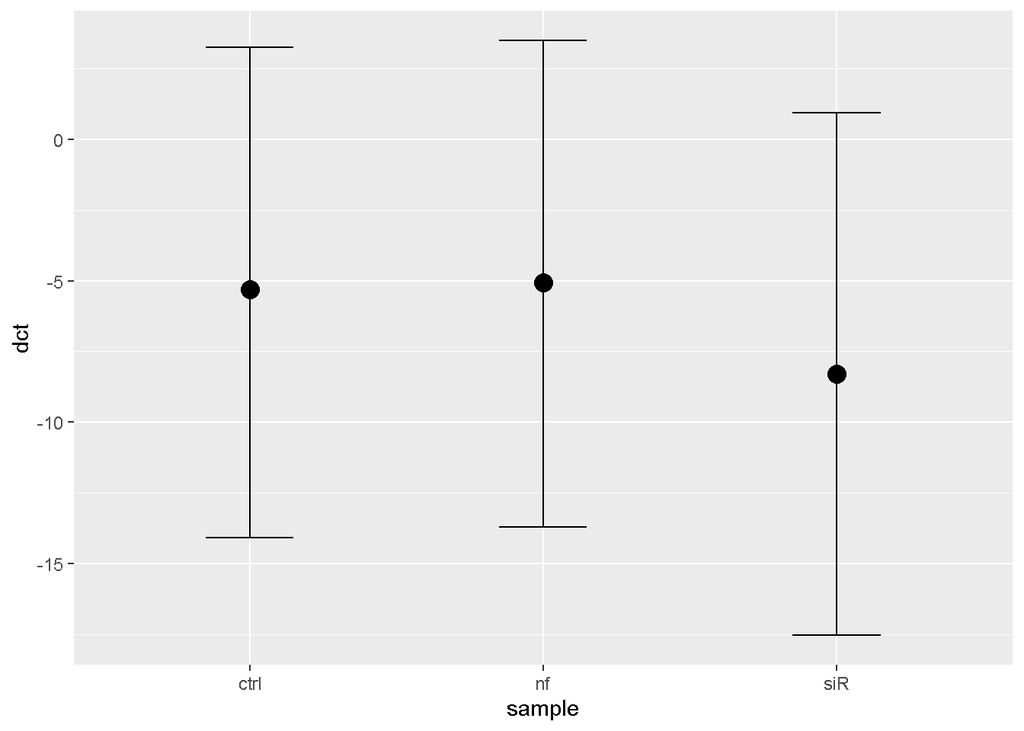

```r
conditional_effects(fit_3.1)
```

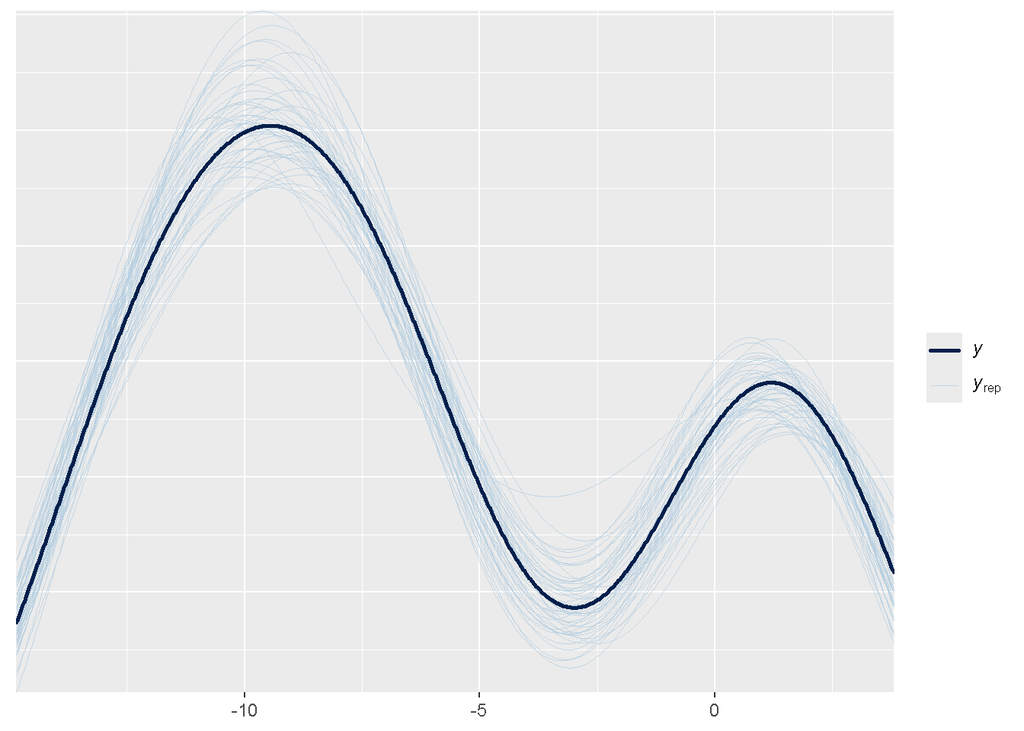

```r
pp_check(fit_3.1, ndraws = 50)
```

```r
bayes_R2(fit_3.1)
```

```
##     Estimate   Est.Error      Q2.5     Q97.5
## R2 0.9905449 0.002155318 0.9851083 0.9931054
```

```r
loo(fit_3.1, 'moment_match = TRUE')
```

```
##
## Computed from 12000 by 27 log-likelihood matrix.
##
##          Estimate  SE
## elpd_loo    -28.4 4.2
## p_loo         9.1 2.3
## looic        56.8 8.4
## ------
## MCSE of elpd_loo is NA.
## MCSE and ESS estimates assume MCMC draws (r_eff in [0.6, 1.0]).
##
## Pareto k diagnostic values:
##                          Count Pct.    Min. ESS
## (-Inf, 0.7]   (good)     25    92.6%   524
##    (0.7, 1]   (bad)       2     7.4%   <NA>
##    (1, Inf)   (very bad)  0     0.0%   <NA>
## See help('pareto-k-diagnostic') for details.
```

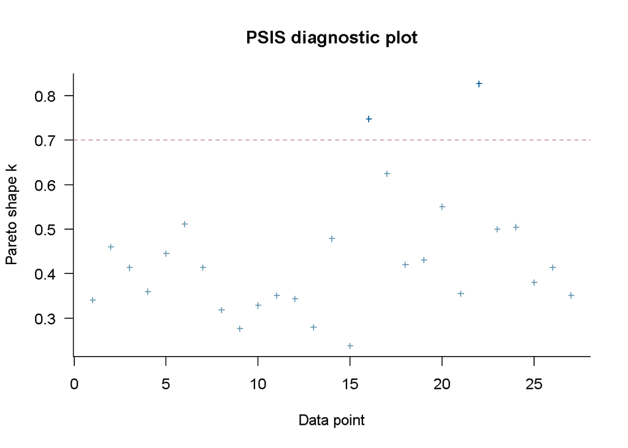

```r
plot(loo(fit_3.1, 'moment_match = TRUE'))
```

### BM3.2

random intercept and random slope are calculated in the same grouping:

```r
### Bayesian model
set.seed = 17

qpcrinvitro$sample <- as.factor(qpcrinvitro$sample)
qpcrinvitro$ct_TBP <- as.numeric(qpcrinvitro$ct_TBP)
qpcrinvitro$ct_MMP9 <- as.numeric(qpcrinvitro$ct_MMP9)
qpcrinvitro$techrep <- as.factor(qpcrinvitro$techrep )
qpcrinvitro$exp <- as.factor(qpcrinvitro$exp )

qpcrinvitro$sample <- relevel(qpcrinvitro$sample, ref = "ctrl")


bform_3.2 <- bf(dct ~ 1 + sample + (1 + sample | exp / techrep))
prior_3.2 <- c(prior(normal(0, 11), class = b, coef = "samplenf"),
             prior(normal(0, 11), class = b, coef = "samplesiR"))

fit_3.2 <- brm(bform_3.2,
            data = qpcrinvitro,
            family = brmsfamily("normal"),
            prior = prior_3.2,
            warmup = 2000,
            iter = 5000,
            chains = 4,
            cores = 4,
            control = list(adapt_delta = 0.95, max_treedepth = 15))
            fit_3.2 <- add_criterion(fit_3.2, "loo")

summary(fit_3.2)
```

```
##  Family: gaussian
##   Links: mu = identity; sigma = identity
## Formula: dct ~ 1 + sample + (1 + sample | exp/techrep)
##    Data: qpcrinvitro (Number of observations: 27)
##   Draws: 4 chains, each with iter = 5000; warmup = 2000; thin = 1;
##          total post-warmup draws = 12000
##
## Group-Level Effects:
## ~exp (Number of levels: 3)
##                          Estimate Est.Error l-95% CI u-95% CI Rhat Bulk_ESS
## sd(Intercept)                7.52      4.22     1.54    17.76 1.00     6747
## sd(samplenf)                 3.14      3.37     0.09    12.01 1.00     4728
## sd(samplesiR)                4.05      3.67     0.16    13.71 1.00     7879
## cor(Intercept,samplenf)     -0.05      0.50    -0.88     0.86 1.00    13615
## cor(Intercept,samplesiR)     0.05      0.49    -0.84     0.88 1.00    12030
## cor(samplenf,samplesiR)      0.00      0.51    -0.88     0.88 1.00    10389
##                          Tail_ESS
## sd(Intercept)                3480
## sd(samplenf)                 6674
## sd(samplesiR)                6554
## cor(Intercept,samplenf)      8261
## cor(Intercept,samplesiR)     8378
## cor(samplenf,samplesiR)      9590
##
## ~exp:techrep (Number of levels: 9)
##                          Estimate Est.Error l-95% CI u-95% CI Rhat Bulk_ESS
## sd(Intercept)                2.12      2.07     0.06     7.50 1.00     3159
## sd(samplenf)                 3.24      3.40     0.08    12.37 1.00     4876
## sd(samplesiR)                4.07      3.66     0.14    13.84 1.00     7384
## cor(Intercept,samplenf)     -0.09      0.51    -0.91     0.86 1.00    12867
## cor(Intercept,samplesiR)    -0.05      0.50    -0.89     0.86 1.00    12172
## cor(samplenf,samplesiR)     -0.00      0.50    -0.89     0.88 1.00     9867
##                          Tail_ESS
## sd(Intercept)                4773
## sd(samplenf)                 6224
## sd(samplesiR)                6193
## cor(Intercept,samplenf)      8061
## cor(Intercept,samplesiR)     8763
## cor(samplenf,samplesiR)      9761
##
## Population-Level Effects:
##           Estimate Est.Error l-95% CI u-95% CI Rhat Bulk_ESS Tail_ESS
## Intercept    -5.05      4.13   -13.49     3.40 1.00     5501     6376
## samplenf      0.12      3.54    -7.53     7.82 1.00     6860     5814
## samplesiR    -3.13      4.04   -11.51     5.59 1.00     6770     6230
##
## Family Specific Parameters:
##       Estimate Est.Error l-95% CI u-95% CI Rhat Bulk_ESS Tail_ESS
## sigma     0.57      0.11     0.41     0.82 1.00     8597     7433
##
## Draws were sampled using sampling(NUTS). For each parameter, Bulk_ESS
## and Tail_ESS are effective sample size measures, and Rhat is the potential
## scale reduction factor on split chains (at convergence, Rhat = 1).
```

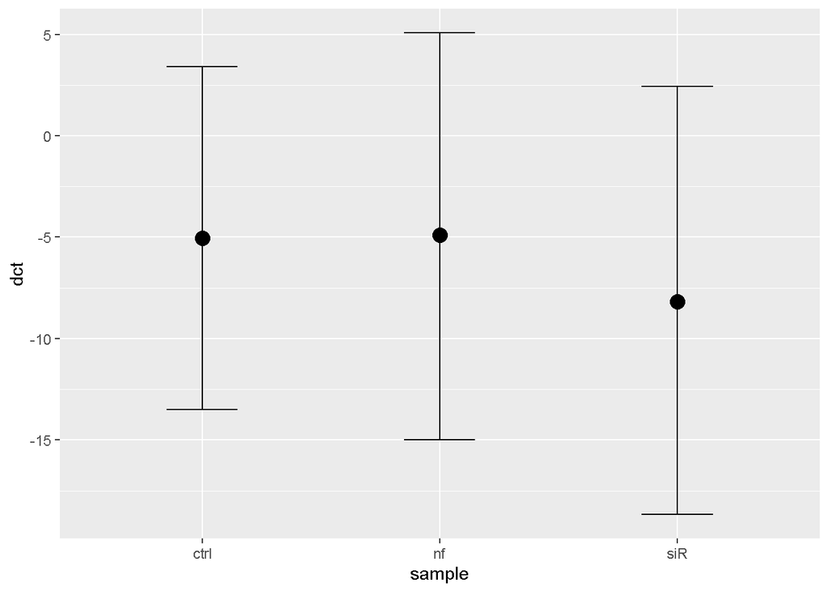

```r
conditional_effects(fit_3.2)
```

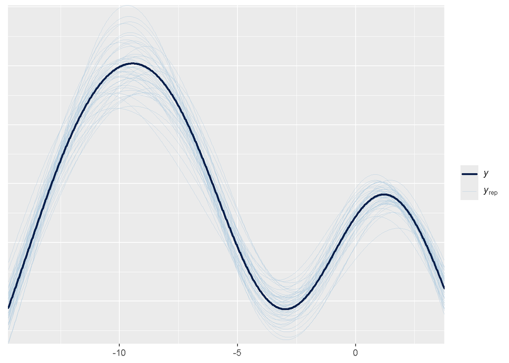

```r
pp_check(fit_3.2, ndraws = 50)
```

```r
bayes_R2(fit_3.2)
```

```
##     Estimate   Est.Error      Q2.5     Q97.5
## R2 0.9904773 0.002265697 0.9845722 0.9930845
```

```r
loo(fit_3.2, 'moment_match = TRUE')
```

```
##
## Computed from 12000 by 27 log-likelihood matrix.
##
##          Estimate  SE
## elpd_loo    -28.5 4.2
## p_loo         9.1 2.2
## looic        56.9 8.3
## ------
## MCSE of elpd_loo is NA.
## MCSE and ESS estimates assume MCMC draws (r_eff in [0.5, 1.0]).
##
## Pareto k diagnostic values:
##                          Count Pct.    Min. ESS
## (-Inf, 0.7]   (good)     25    92.6%   280
##    (0.7, 1]   (bad)       2     7.4%   <NA>
##    (1, Inf)   (very bad)  0     0.0%   <NA>
## See help('pareto-k-diagnostic') for details.
```

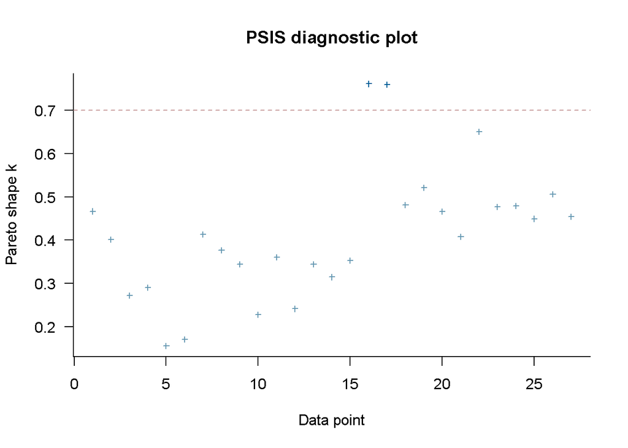

```r
plot(loo(fit_3.2, 'moment_match = TRUE'))
```

### BM3.5

random intercept for the experiment only:

```r
### Bayesian model
set.seed = 17

qpcrinvitro$sample <- as.factor(qpcrinvitro$sample)
qpcrinvitro$ct_TBP <- as.numeric(qpcrinvitro$ct_TBP)
qpcrinvitro$ct_MMP9 <- as.numeric(qpcrinvitro$ct_MMP9)
qpcrinvitro$techrep <- as.factor(qpcrinvitro$techrep )
qpcrinvitro$exp <- as.factor(qpcrinvitro$exp )

qpcrinvitro$sample <- relevel(qpcrinvitro$sample, ref = "ctrl")


bform_3.5 <- bf(dct ~ 1 + sample + (1 | exp))
prior_3.5 <- c(prior(normal(0, 11), class = b, coef = "samplenf"),
             prior(normal(0, 11), class = b, coef = "samplesiR"))

fit_3.5 <- brm(bform_3.5,
            data = qpcrinvitro,
            family = brmsfamily("normal"),
            prior = prior_3.5,
            warmup = 2000,
            iter = 5000,
            chains = 4,
            cores = 4,
            control = list(adapt_delta = 0.95, max_treedepth = 15))
            fit_3.5 <- add_criterion(fit_3.5, "loo")

summary(fit_3.5)
```

```
##  Family: gaussian
##   Links: mu = identity; sigma = identity
## Formula: dct ~ 1 + sample + (1 | exp)
##    Data: qpcrinvitro (Number of observations: 27)
##   Draws: 4 chains, each with iter = 5000; warmup = 2000; thin = 1;
##          total post-warmup draws = 12000
##
## Group-Level Effects:
## ~exp (Number of levels: 3)
##               Estimate Est.Error l-95% CI u-95% CI Rhat Bulk_ESS Tail_ESS
## sd(Intercept)     7.74      3.92     3.30    18.04 1.00     3902     4817
##
## Population-Level Effects:
##           Estimate Est.Error l-95% CI u-95% CI Rhat Bulk_ESS Tail_ESS
## Intercept    -5.14      3.96   -13.34     2.58 1.00     3536     3928
## samplenf      0.10      0.58    -1.03     1.28 1.00     6948     6097
## samplesiR    -3.37      0.58    -4.52    -2.25 1.00     7099     7027
##
## Family Specific Parameters:
##       Estimate Est.Error l-95% CI u-95% CI Rhat Bulk_ESS Tail_ESS
## sigma     1.21      0.20     0.90     1.67 1.00     6679     6672
##
## Draws were sampled using sampling(NUTS). For each parameter, Bulk_ESS
## and Tail_ESS are effective sample size measures, and Rhat is the potential
## scale reduction factor on split chains (at convergence, Rhat = 1).
```

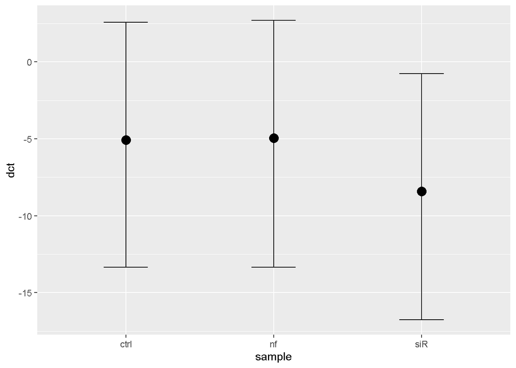

```r
conditional_effects(fit_3.5)
```

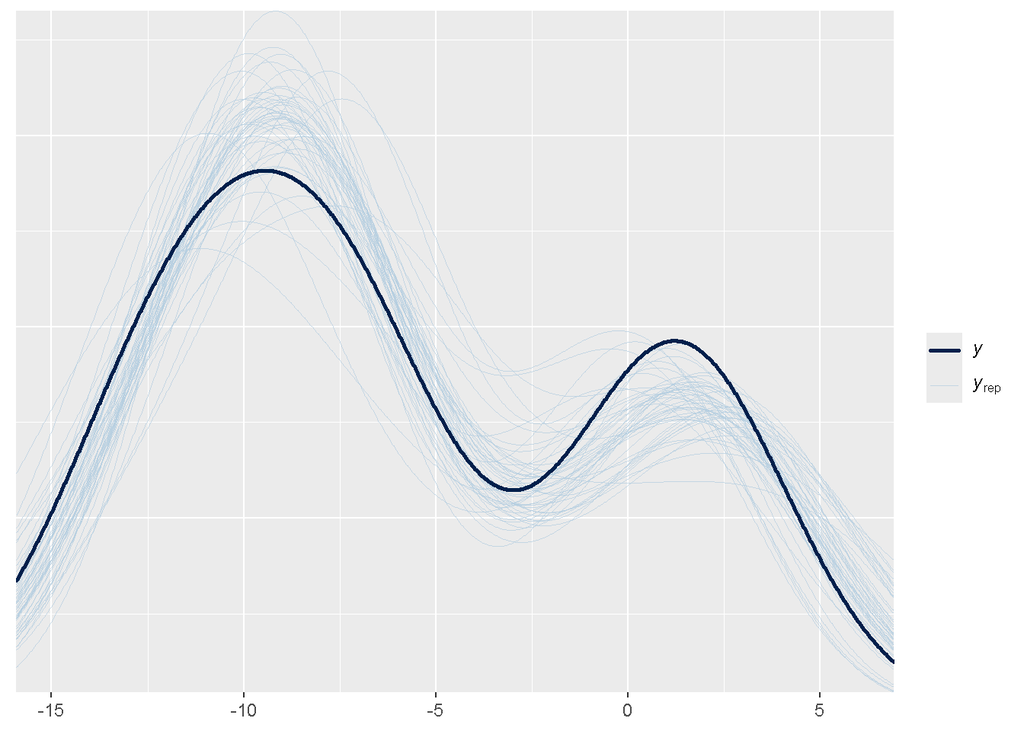

```r
pp_check(fit_3.5, ndraws = 50)
```

```r
bayes_R2(fit_3.5)
```

```
##     Estimate   Est.Error     Q2.5     Q97.5
## R2 0.9575305 0.007397871 0.938173 0.9652941
```

```r
loo(fit_3.5, 'moment_match = TRUE')
```

```
##
## Computed from 12000 by 27 log-likelihood matrix.
##
##          Estimate  SE
## elpd_loo    -46.0 4.0
## p_loo         5.5 1.6
## looic        92.1 7.9
## ------
## MCSE of elpd_loo is 0.1.
## MCSE and ESS estimates assume MCMC draws (r_eff in [0.5, 1.0]).
##
## All Pareto k estimates are good (k < 0.7).
## See help('pareto-k-diagnostic') for details.
```

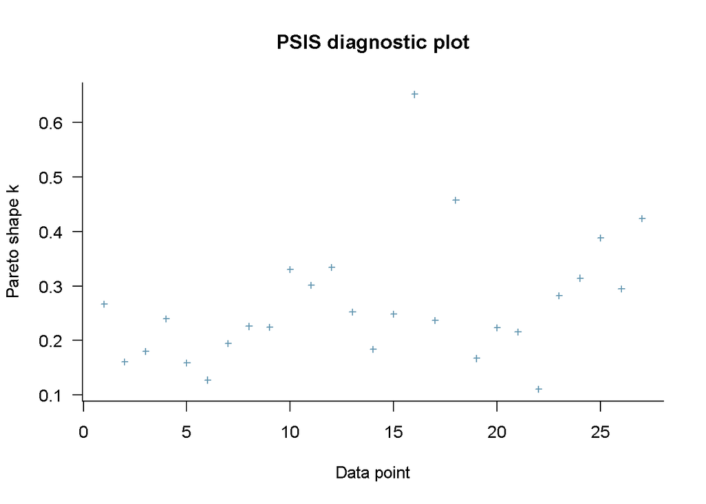

```r
plot(loo(fit_3.5, 'moment_match = TRUE'))
```

### BM3.6

model with the fixed factor only:

```r
### Bayesian model
set.seed = 17

qpcrinvitro$sample <- as.factor(qpcrinvitro$sample)
qpcrinvitro$ct_TBP <- as.numeric(qpcrinvitro$ct_TBP)
qpcrinvitro$ct_MMP9 <- as.numeric(qpcrinvitro$ct_MMP9)
qpcrinvitro$techrep <- as.factor(qpcrinvitro$techrep )
qpcrinvitro$exp <- as.factor(qpcrinvitro$exp )

qpcrinvitro$sample <- relevel(qpcrinvitro$sample, ref = "ctrl")


bform_3.6 <- bf(dct ~ 1 + sample )
prior_3.6 <- c(prior(normal(0, 11), class = b, coef = "samplenf"),
             prior(normal(0, 11), class = b, coef = "samplesiR"))

fit_3.6 <- brm(bform_3.6,
            data = qpcrinvitro,
            family = brmsfamily("normal"),
            prior = prior_3.6,
            warmup = 2000,
            iter = 5000,
            chains = 4,
            cores = 4,
            control = list(adapt_delta = 0.95, max_treedepth = 15))
            fit_3.6 <- add_criterion(fit_3.6, "loo")

summary(fit_3.6)
```

```
##  Family: gaussian
##   Links: mu = identity; sigma = identity
## Formula: dct ~ 1 + sample
##    Data: qpcrinvitro (Number of observations: 27)
##   Draws: 4 chains, each with iter = 5000; warmup = 2000; thin = 1;
##          total post-warmup draws = 12000
##
## Population-Level Effects:
##           Estimate Est.Error l-95% CI u-95% CI Rhat Bulk_ESS Tail_ESS
## Intercept    -4.99      1.90    -8.78    -1.31 1.00     8449     7625
## samplenf      0.17      2.68    -5.04     5.53 1.00     8342     8293
## samplesiR    -3.20      2.66    -8.39     2.02 1.00     8742     7901
##
## Family Specific Parameters:
##       Estimate Est.Error l-95% CI u-95% CI Rhat Bulk_ESS Tail_ESS
## sigma     5.82      0.87     4.41     7.81 1.00    10056     8514
##
## Draws were sampled using sampling(NUTS). For each parameter, Bulk_ESS
## and Tail_ESS are effective sample size measures, and Rhat is the potential
## scale reduction factor on split chains (at convergence, Rhat = 1).
```

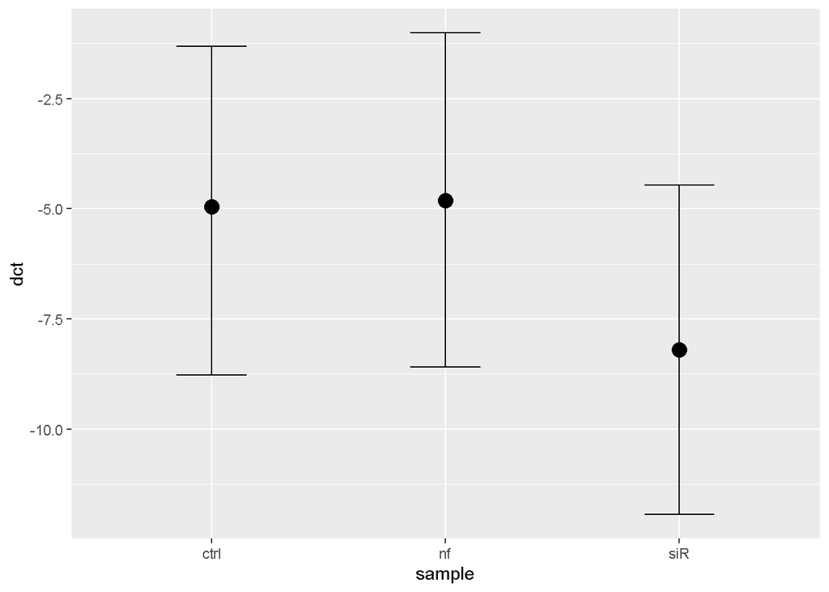

```r
conditional_effects(fit_3.6)
```

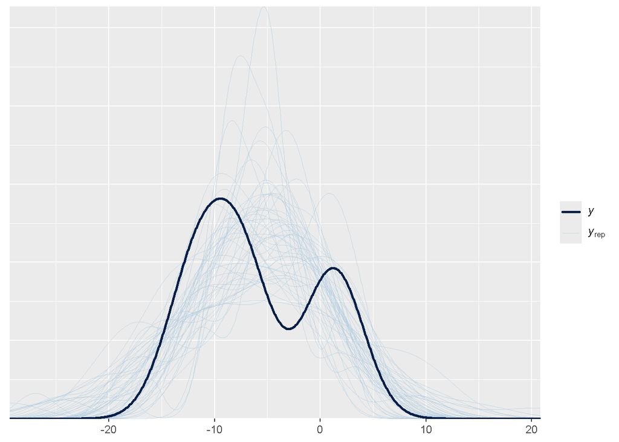

```r
pp_check(fit_3.6, ndraws = 50)
```

```r
bayes_R2(fit_3.6)
```

```
##     Estimate  Est.Error        Q2.5     Q97.5
## R2 0.1242478 0.08484065 0.005695819 0.3115081
```

```r
loo(fit_3.6, 'moment_match = TRUE')
```

```
##
## Computed from 12000 by 27 log-likelihood matrix.
##
##          Estimate  SE
## elpd_loo    -87.0 2.0
## p_loo         3.0 0.4
## looic       173.9 4.1
## ------
## MCSE of elpd_loo is 0.0.
## MCSE and ESS estimates assume MCMC draws (r_eff in [0.7, 1.1]).
##
## All Pareto k estimates are good (k < 0.7).
## See help('pareto-k-diagnostic') for details.
```

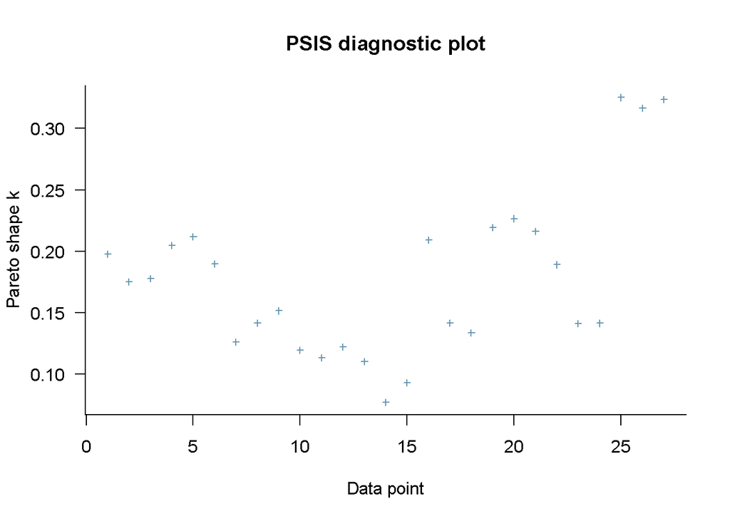

```r
plot(loo(fit_3.6, 'moment_match = TRUE'))
```

Comparison of models. The results of the cross-validation show that models BM3, BM3.1 and BM3.2 are comparable and outperform models BM3.5 and BM3.6.

Modeling the random slope for models BM3.1 and BM3.2 represents additional complexity compared to model BM3 (BM3 includes only random intercept) which does not bring noticeable improvement. Thus, let’s stick to our initial expectation (model BM3 model).

```r
loo(fit_3, fit_3.1, fit_3.2, fit_3.5, fit_3.6)
```

```
## Output of model 'fit_3':
##
## Computed from 12000 by 27 log-likelihood matrix.
##
##          Estimate  SE
## elpd_loo    -28.6 4.1
## p_loo         9.2 2.2
## looic        57.1 8.2
## ------
## MCSE of elpd_loo is NA.
## MCSE and ESS estimates assume MCMC draws (r_eff in [0.5, 1.1]).
##
## Pareto k diagnostic values:
##                          Count Pct.    Min. ESS
## (-Inf, 0.7]   (good)     25    92.6%   438
##    (0.7, 1]   (bad)       2     7.4%   <NA>
##    (1, Inf)   (very bad)  0     0.0%   <NA>
## See help('pareto-k-diagnostic') for details.
##
## Output of model 'fit_3.1':
##
## Computed from 12000 by 27 log-likelihood matrix.
##
##          Estimate  SE
## elpd_loo    -28.4 4.2
## p_loo         9.1 2.3
## looic        56.8 8.4
## ------
## MCSE of elpd_loo is NA.
## MCSE and ESS estimates assume MCMC draws (r_eff in [0.6, 1.0]).
##
## Pareto k diagnostic values:
##                          Count Pct.    Min. ESS
## (-Inf, 0.7]   (good)     25    92.6%   524
##    (0.7, 1]   (bad)       2     7.4%   <NA>
##    (1, Inf)   (very bad)  0     0.0%   <NA>
## See help('pareto-k-diagnostic') for details.
##
## Output of model 'fit_3.2':
##
```

[output cut: 39 more lines]

```
## looic       173.9 4.1
## ------
## MCSE of elpd_loo is 0.0.
## MCSE and ESS estimates assume MCMC draws (r_eff in [0.7, 1.1]).
##
## All Pareto k estimates are good (k < 0.7).
## See help('pareto-k-diagnostic') for details.
##
## Model comparisons:
##         elpd_diff se_diff
## fit_3.1   0.0       0.0
## fit_3.2   0.0       0.3
## fit_3    -0.1       0.4
## fit_3.5 -17.6       4.7
## fit_3.6 -58.6       4.3
```

Let’s take a look at the group-level estimates (just out of interest):

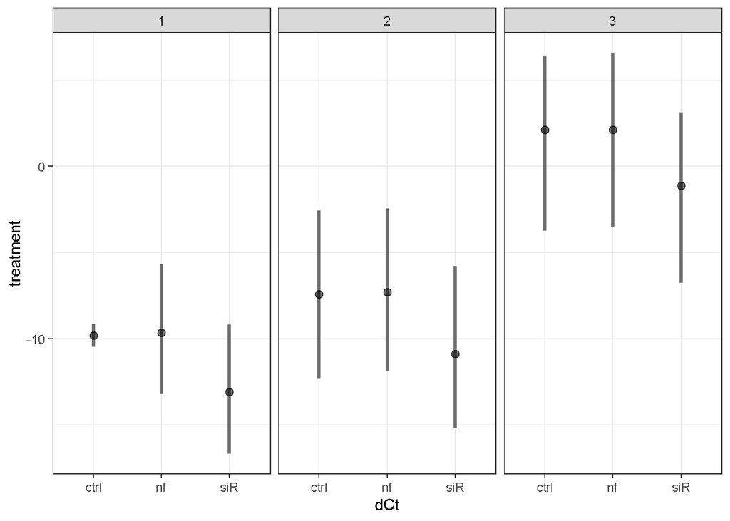

```r
pred <- predictions(fit_3,
    newdata = datagrid(sample = c("ctrl", "nf", "siR"),
                       exp = unique),
    re_formula = ~(1|exp / techrep),
    allow_new_levels = TRUE,
    type = "response", ### posterior_epred method
    by = c("sample", "exp"))

pred <-  posterior_draws(pred)
pred %>%
        ggplot(aes(y = draw,
                   x = sample,
                   alpha = 1)) +
        # stat_halfeye() +
  stat_pointinterval(.width = c(0.95),
                    point_interval = "median_qi")+
  theme_bw() +
  theme(legend.position = "none") +
  facet_grid(~exp) +
  labs(x = "dCt", y = "treatment")
```

Plot the final effect size (population-level estimates). Let’s try different implementations first to see that everything is ok:

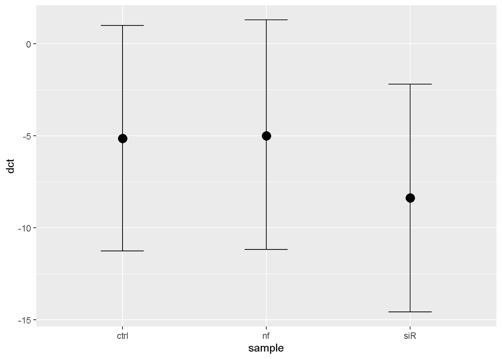

```r
### [1]
conditional_effects(fit_3, conditions = NULL, re_formula = NA, method = "posterior_epred", prob = 0.89, ask = FALSE)
```

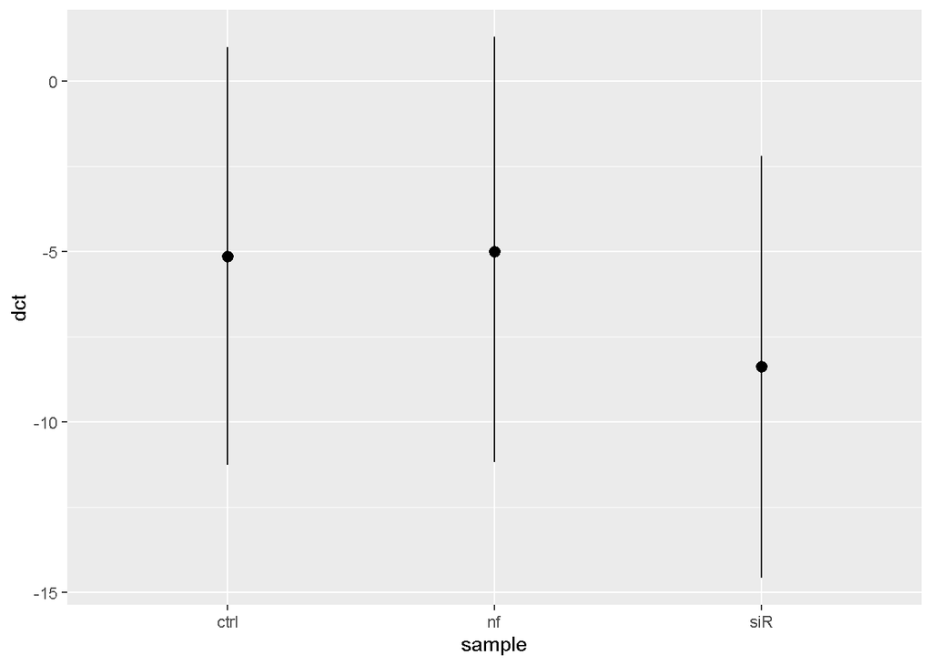

```r
### [2]
plot_predictions(fit_3, condition = "sample", type = "response", re_formula = NA, conf_level = 0.89)
```

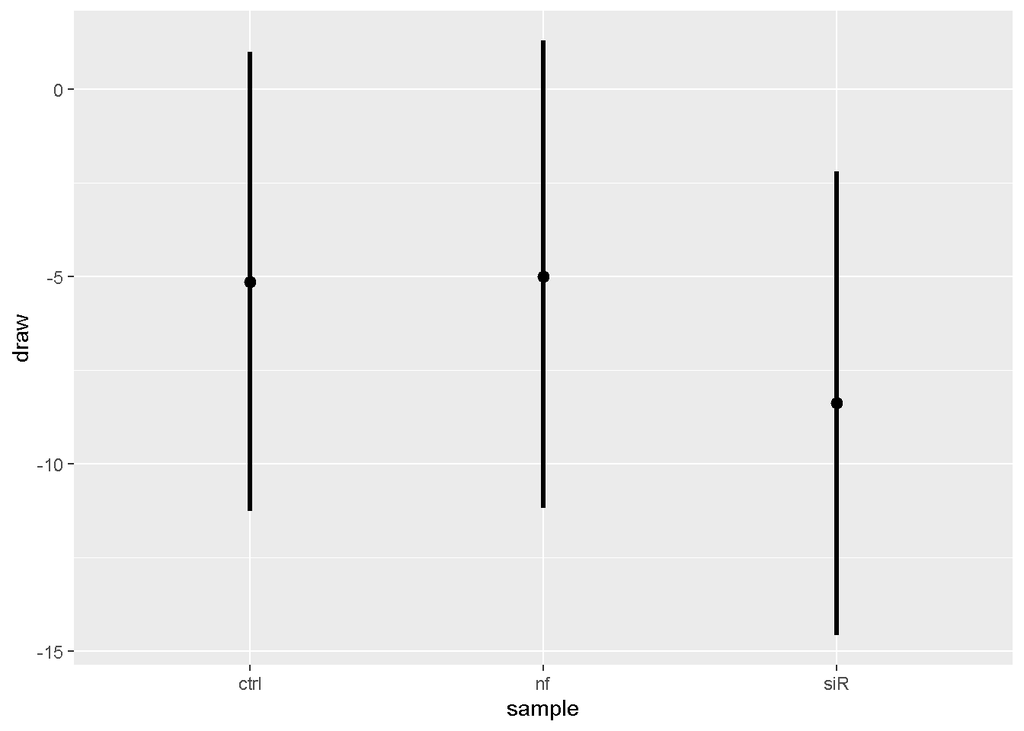

```r
### [3]
pred1 <- predictions(fit_3,
                    type = "response",
                    re_formula = NA,
                    conf_level = 0.89)
pred1 <- posterior_draws(pred1)
ggplot(pred1, aes(y = draw, x = sample)) +
    stat_pointinterval(.width = c(0.89))
```

Plot the full posterior distributions (Figure 4B):

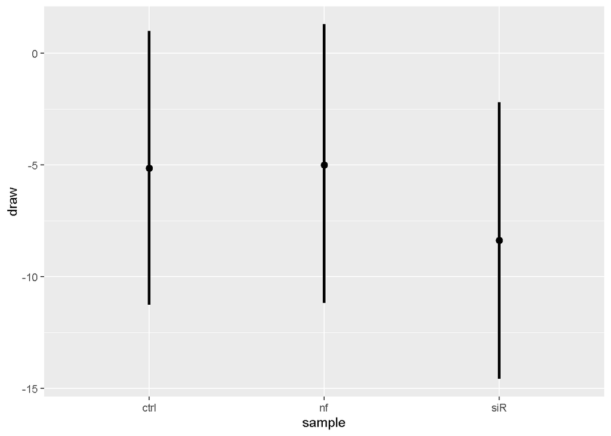

```r
pred1 <- predictions(fit_3,
                     type = "response",
                     re_formula = NA,
                     conf_level = 0.89)
pred1 <- posterior_draws(pred1)
ggplot(pred1, aes(y = draw, x = sample)) +
stat_pointinterval(.width = c(0.89))
```

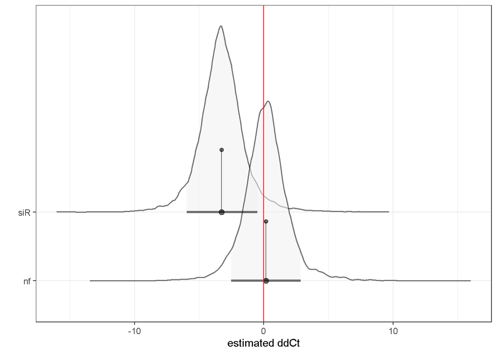

```r
pred1_compare <-
  pred1 %>%
  group_by(drawid, exp, sample) %>%
  distinct(draw, .keep_all = TRUE) %>%
  ungroup() %>%
  group_by(drawid, exp) %>%
  mutate(diff = draw - draw[sample == "ctrl"]) %>%
  filter(sample != "ctrl") %>%
  ungroup()


pred1_compare %>%
      ggplot(aes(x = diff,
                 y = sample,
                 alpha = 0.8)) +
        stat_halfeye(aes(fill = after_stat(level)),    # area under curve colors
               point_interval = mean_qi,         # circle = mean + quantile intervals
               .width = c(.89),         # areas under curve
               slab_color = "#000000",           # posterior curve color
               slab_linewidth = 0.7,
               height = 3) +
               stat_spike(at = c(mean)) +
  scale_fill_brewer(type = "seq",                # collor pallete - area under curve
                    palette = "Greys",
                    direction = 1,
                    aesthetics = "fill") +
  theme_bw() +
  theme(legend.position = "none") +
  geom_vline(xintercept = 0, color = "red") +
  labs(x = "estimated ddCt", y = "")
```

### BM3.7

Prior sensitivity analysis for BM3: Try to check the more narrower prior.

```r
### Bayesian model
set.seed = 17


bform_3.7 <- bf(dct ~ 1 + sample + (1 | exp / techrep))
prior_3.7 <- c(prior(normal(0, 2), class = b, coef = "samplenf"),
             prior(normal(0, 2), class = b, coef = "samplesiR"))

fit_3.7 <- brm(bform_3.7,
            data = qpcrinvitro,
            family = brmsfamily("normal"),
            prior = prior_3.7,
            warmup = 2000,
            iter = 5000,
            chains = 4,
            cores = 4,
            control = list(adapt_delta = 0.95, max_treedepth = 15))
            fit_3.7 <- add_criterion(fit_3.7, "loo")

summary(fit_3.7)
```

```
##  Family: gaussian
##   Links: mu = identity; sigma = identity
## Formula: dct ~ 1 + sample + (1 | exp/techrep)
##    Data: qpcrinvitro (Number of observations: 27)
##   Draws: 4 chains, each with iter = 5000; warmup = 2000; thin = 1;
##          total post-warmup draws = 12000
##
## Group-Level Effects:
## ~exp (Number of levels: 3)
##               Estimate Est.Error l-95% CI u-95% CI Rhat Bulk_ESS Tail_ESS
## sd(Intercept)     7.61      3.91     2.96    18.09 1.00     5703     2912
##
## ~exp:techrep (Number of levels: 9)
##               Estimate Est.Error l-95% CI u-95% CI Rhat Bulk_ESS Tail_ESS
## sd(Intercept)     1.95      0.97     0.83     4.50 1.00     3353     4978
##
## Population-Level Effects:
##           Estimate Est.Error l-95% CI u-95% CI Rhat Bulk_ESS Tail_ESS
## Intercept    -5.60      3.94   -13.83     2.28 1.00     7304     6793
## samplenf      0.41      1.20    -1.93     2.86 1.00     6664     2461
## samplesiR    -2.21      1.31    -4.48     0.72 1.00     7293     7595
##
## Family Specific Parameters:
##       Estimate Est.Error l-95% CI u-95% CI Rhat Bulk_ESS Tail_ESS
## sigma     0.58      0.11     0.41     0.83 1.00     6320     3436
##
## Draws were sampled using sampling(NUTS). For each parameter, Bulk_ESS
## and Tail_ESS are effective sample size measures, and Rhat is the potential
## scale reduction factor on split chains (at convergence, Rhat = 1).
```

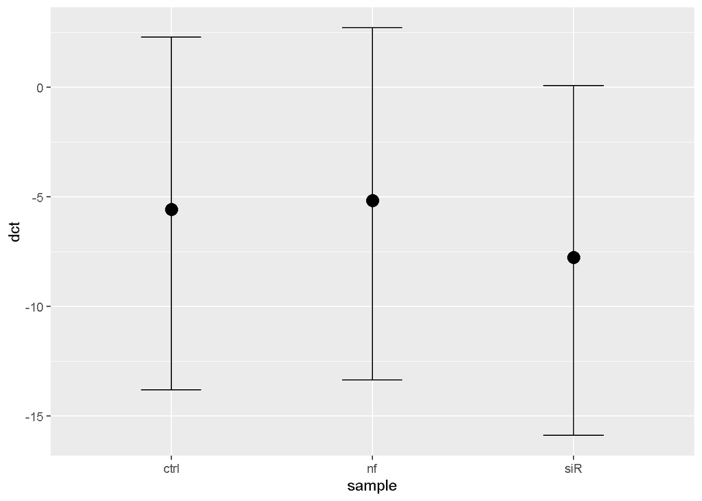

```r
conditional_effects(fit_3.7)
```

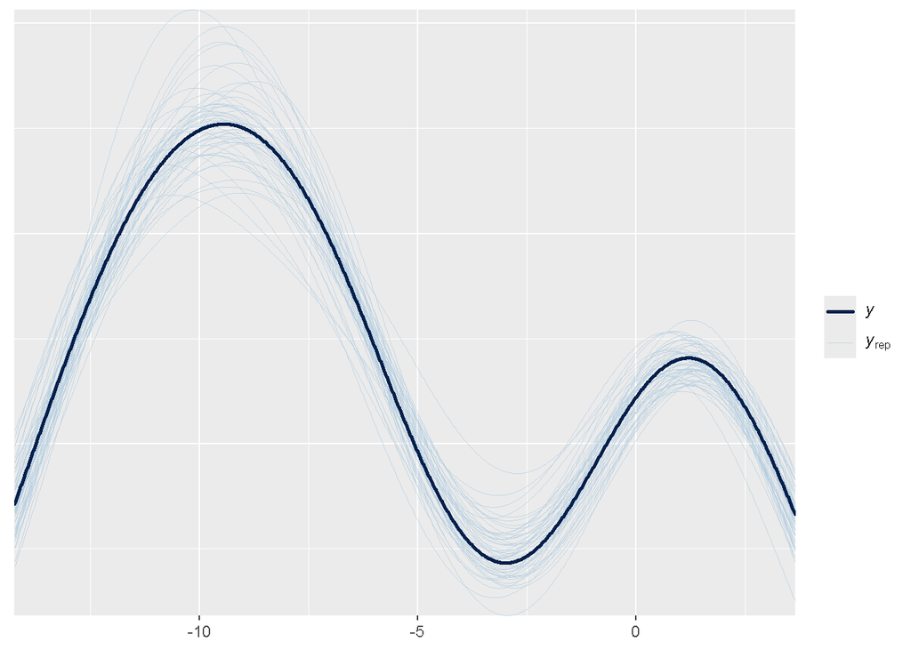

```r
pp_check(fit_3.7, ndraws = 50)
```

```r
bayes_R2(fit_3.7)
```

```
##     Estimate   Est.Error      Q2.5     Q97.5
## R2 0.9903777 0.002348595 0.9841209 0.9931064
```

```r
loo(fit_3.7, 'moment_match = TRUE')
```

```
##
## Computed from 12000 by 27 log-likelihood matrix.
##
##          Estimate  SE
## elpd_loo    -28.5 4.1
## p_loo         9.1 2.2
## looic        56.9 8.2
## ------
## MCSE of elpd_loo is NA.
## MCSE and ESS estimates assume MCMC draws (r_eff in [0.5, 1.0]).
##
## Pareto k diagnostic values:
##                          Count Pct.    Min. ESS
## (-Inf, 0.7]   (good)     26    96.3%   314
##    (0.7, 1]   (bad)       1     3.7%   <NA>
##    (1, Inf)   (very bad)  0     0.0%   <NA>
## See help('pareto-k-diagnostic') for details.
```

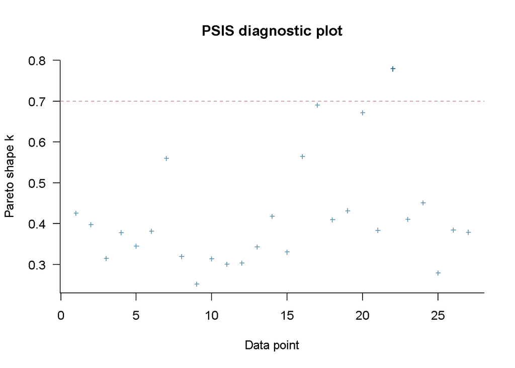

```r
plot(loo(fit_3.7, 'moment_match = TRUE'))
```

```r
library(emmeans)
fixef(fit_3.7) ### population-level (fixed) effects
```

```
##             Estimate Est.Error       Q2.5     Q97.5
## Intercept -5.6049650  3.935188 -13.828060 2.2836625
## samplenf   0.4093285  1.195532  -1.926221 2.8566441
## samplesiR -2.2128569  1.311880  -4.477557 0.7229307
```

```r
ranef(fit_3.7) ### group-level (random) effects
```

```
## $exp
## , , Intercept
##
##    Estimate Est.Error        Q2.5     Q97.5
## 1 -4.007971  3.994276 -12.3329582  4.057501
## 2 -2.393715  3.938218 -10.3525011  5.587236
## 3  7.155822  4.011188  -0.7154691 15.402749
##
##
## $`exp:techrep`
## , , Intercept
##
##        Estimate Est.Error      Q2.5     Q97.5
## 1_1 -0.21325501  1.430116 -3.164967 2.6777635
## 1_2 -0.07802288  1.501023 -3.323066 2.8924050
## 1_3 -0.37907484  1.611867 -4.171421 2.3465218
## 2_4  1.14101050  1.404463 -1.590434 4.0949188
## 2_5  0.92308297  1.491248 -1.984068 4.0723113
## 2_6 -2.50688997  1.562188 -6.123615 0.1097351
## 3_7  0.46545786  1.569755 -2.134250 4.0800800
## 3_8 -0.36794240  1.636881 -3.246100 3.3952398
## 3_9  0.88703223  1.504825 -2.059794 3.9775996
```

```r
coef(fit_3.7)  ### extract combined coefficients
```

```
## $exp
## , , Intercept
##
##    Estimate Est.Error       Q2.5     Q97.5
## 1 -9.612936  1.432527 -12.521796 -6.682647
## 2 -7.998680  1.396047 -10.912641 -5.269557
## 3  1.550858  1.567767  -2.039645  4.172193
##
## , , samplenf
##
##    Estimate Est.Error      Q2.5    Q97.5
## 1 0.4093285  1.195532 -1.926221 2.856644
## 2 0.4093285  1.195532 -1.926221 2.856644
## 3 0.4093285  1.195532 -1.926221 2.856644
##
## , , samplesiR
##
##    Estimate Est.Error      Q2.5     Q97.5
## 1 -2.212857   1.31188 -4.477557 0.7229307
## 2 -2.212857   1.31188 -4.477557 0.7229307
## 3 -2.212857   1.31188 -4.477557 0.7229307
##
##
## $`exp:techrep`
## , , Intercept
##
##      Estimate Est.Error      Q2.5     Q97.5
## 1_1 -5.818220  3.998709 -13.86526 2.4691542
## 1_2 -5.682988  4.149400 -14.08426 2.6849823
## 1_3 -5.984040  4.237731 -14.63321 2.5383679
## 2_4 -4.463954  3.944807 -12.49963 3.4806249
## 2_5 -4.681882  4.107774 -13.00848 3.5361104
## 2_6 -8.111855  4.173632 -16.52927 0.2619475
## 3_7 -5.139507  4.016077 -13.40752 2.7209484
## 3_8 -5.972907  4.170397 -14.63091 2.3203253
## 3_9 -4.717933  4.168341 -13.48902 3.4240920
##
## , , samplenf
##
##      Estimate Est.Error      Q2.5    Q97.5
## 1_1 0.4093285  1.195532 -1.926221 2.856644
## 1_2 0.4093285  1.195532 -1.926221 2.856644
## 1_3 0.4093285  1.195532 -1.926221 2.856644
## 2_4 0.4093285  1.195532 -1.926221 2.856644
## 2_5 0.4093285  1.195532 -1.926221 2.856644
## 2_6 0.4093285  1.195532 -1.926221 2.856644
## 3_7 0.4093285  1.195532 -1.926221 2.856644
## 3_8 0.4093285  1.195532 -1.926221 2.856644
## 3_9 0.4093285  1.195532 -1.926221 2.856644
##
## , , samplesiR
##
##      Estimate Est.Error      Q2.5     Q97.5
## 1_1 -2.212857   1.31188 -4.477557 0.7229307
## 1_2 -2.212857   1.31188 -4.477557 0.7229307
## 1_3 -2.212857   1.31188 -4.477557 0.7229307
## 2_4 -2.212857   1.31188 -4.477557 0.7229307
## 2_5 -2.212857   1.31188 -4.477557 0.7229307
## 2_6 -2.212857   1.31188 -4.477557 0.7229307
## 3_7 -2.212857   1.31188 -4.477557 0.7229307
## 3_8 -2.212857   1.31188 -4.477557 0.7229307
## 3_9 -2.212857   1.31188 -4.477557 0.7229307
```

### BM3.8

Prior sensitivity analysis for BM3: Try to check the more wider prior.

```r
### Bayesian model
set.seed = 17


bform_3.8 <- bf(dct ~ 1 + sample + (1 | exp / techrep))
prior_3.8 <- c(prior(normal(0, 20), class = b, coef = "samplenf"),
             prior(normal(0, 20), class = b, coef = "samplesiR"))

fit_3.8 <- brm(bform_3.8,
            data = qpcrinvitro,
            family = brmsfamily("normal"),
            prior = prior_3.8,
            warmup = 2000,
            iter = 5000,
            chains = 4,
            cores = 4,
            control = list(adapt_delta = 0.95, max_treedepth = 15))
            fit_3.8 <- add_criterion(fit_3.8, "loo")

summary(fit_3.8)
```

```
##  Family: gaussian
##   Links: mu = identity; sigma = identity
## Formula: dct ~ 1 + sample + (1 | exp/techrep)
##    Data: qpcrinvitro (Number of observations: 27)
##   Draws: 4 chains, each with iter = 5000; warmup = 2000; thin = 1;
##          total post-warmup draws = 12000
##
## Group-Level Effects:
## ~exp (Number of levels: 3)
##               Estimate Est.Error l-95% CI u-95% CI Rhat Bulk_ESS Tail_ESS
## sd(Intercept)     7.44      3.73     2.82    17.32 1.00     6041     6058
##
## ~exp:techrep (Number of levels: 9)
##               Estimate Est.Error l-95% CI u-95% CI Rhat Bulk_ESS Tail_ESS
## sd(Intercept)     2.12      1.27     0.83     5.62 1.00     2700     3160
##
## Population-Level Effects:
##           Estimate Est.Error l-95% CI u-95% CI Rhat Bulk_ESS Tail_ESS
## Intercept    -5.04      3.93   -13.13     2.83 1.00     5695     6218
## samplenf      0.12      1.99    -3.75     4.25 1.00     5853     4037
## samplesiR    -3.34      1.94    -7.10     0.67 1.00     5616     4040
##
## Family Specific Parameters:
##       Estimate Est.Error l-95% CI u-95% CI Rhat Bulk_ESS Tail_ESS
## sigma     0.57      0.10     0.41     0.81 1.00     8518     7783
##
## Draws were sampled using sampling(NUTS). For each parameter, Bulk_ESS
## and Tail_ESS are effective sample size measures, and Rhat is the potential
## scale reduction factor on split chains (at convergence, Rhat = 1).
```

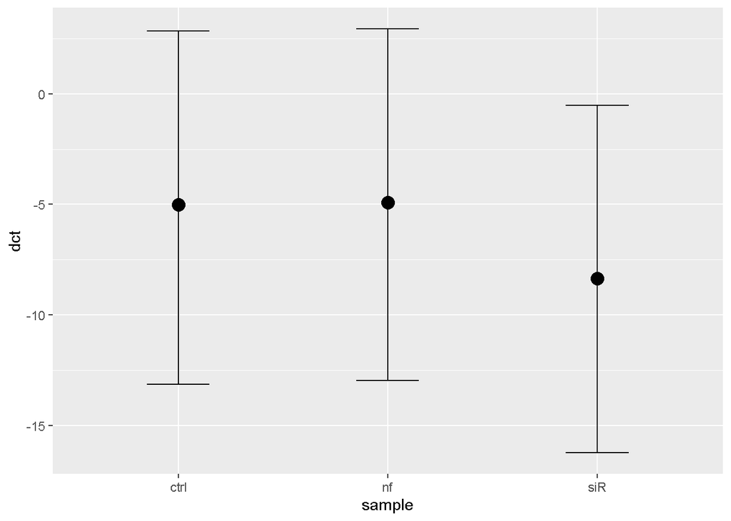

```r
conditional_effects(fit_3.8)
```

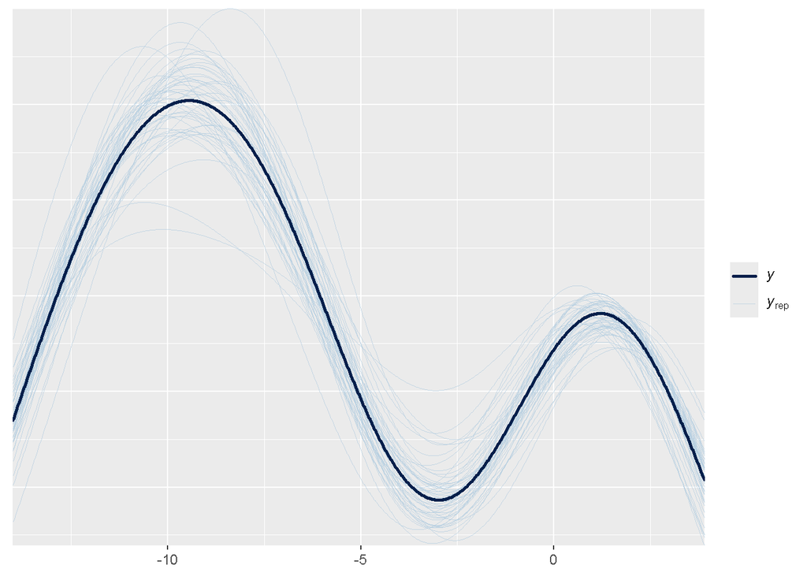

```r
pp_check(fit_3.8, ndraws = 50)
```

```r
bayes_R2(fit_3.8)
```

```
##     Estimate   Est.Error      Q2.5     Q97.5
## R2 0.9904888 0.002221588 0.9847256 0.9931054
```

```r
loo(fit_3.8, 'moment_match = TRUE')
```

```
##
## Computed from 12000 by 27 log-likelihood matrix.
##
##          Estimate  SE
## elpd_loo    -28.5 4.1
## p_loo         9.2 2.2
## looic        57.0 8.3
## ------
## MCSE of elpd_loo is NA.
## MCSE and ESS estimates assume MCMC draws (r_eff in [0.5, 1.0]).
##
## Pareto k diagnostic values:
##                          Count Pct.    Min. ESS
## (-Inf, 0.7]   (good)     25    92.6%   293
##    (0.7, 1]   (bad)       2     7.4%   <NA>
##    (1, Inf)   (very bad)  0     0.0%   <NA>
## See help('pareto-k-diagnostic') for details.
```

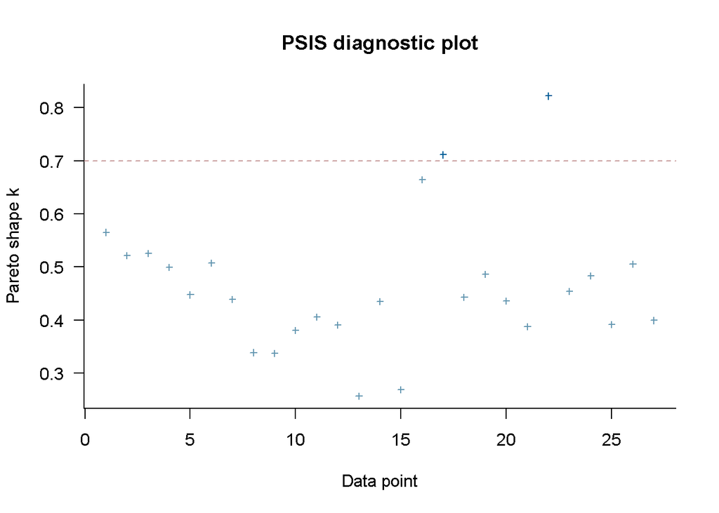

```r
plot(loo(fit_3.8, 'moment_match = TRUE'))
```

```r
library(emmeans)
fixef(fit_3.8) ### population-level (fixed) effects
```

```
##             Estimate Est.Error       Q2.5     Q97.5
## Intercept -5.0394548  3.925162 -13.134026 2.8344040
## samplenf   0.1189592  1.987957  -3.749936 4.2531934
## samplesiR -3.3384170  1.940317  -7.100408 0.6705318
```

```r
ranef(fit_3.8) ### group-level (random) effects
```

```
## $exp
## , , Intercept
##
##    Estimate Est.Error        Q2.5     Q97.5
## 1 -4.060302  3.876669 -11.8935978  3.843779
## 2 -2.497326  3.860392 -10.3972572  5.321659
## 3  6.968571  3.975793  -0.7806647 15.201307
##
##
## $`exp:techrep`
## , , Intercept
##
##        Estimate Est.Error      Q2.5    Q97.5
## 1_1 -0.71204551  1.799983 -4.662754 2.643897
## 1_2 -0.30558950  1.895855 -4.535475 3.037646
## 1_3  0.21036175  1.823734 -3.891344 3.490662
## 2_4  0.70079335  1.770064 -3.017610 4.267784
## 2_5  0.75418230  1.809145 -3.108542 4.160201
## 2_6 -1.86475008  1.759138 -5.641739 1.466543
## 3_7  0.09691526  1.939873 -3.152599 4.794776
## 3_8 -0.45735165  1.907744 -3.874195 3.937591
## 3_9  1.61909837  1.901567 -1.651508 6.141616
```

```r
coef(fit_3.8)  ### extract combined coefficients
```

```
## $exp
## , , Intercept
##
##    Estimate Est.Error       Q2.5     Q97.5
## 1 -9.099757  1.802268 -12.503331 -5.105821
## 2 -7.536780  1.779498 -11.149994 -3.754458
## 3  1.929116  1.945899  -2.791962  5.219658
##
## , , samplenf
##
##    Estimate Est.Error      Q2.5    Q97.5
## 1 0.1189592  1.987957 -3.749936 4.253193
## 2 0.1189592  1.987957 -3.749936 4.253193
## 3 0.1189592  1.987957 -3.749936 4.253193
##
## , , samplesiR
##
##    Estimate Est.Error      Q2.5     Q97.5
## 1 -3.338417  1.940317 -7.100408 0.6705318
## 2 -3.338417  1.940317 -7.100408 0.6705318
## 3 -3.338417  1.940317 -7.100408 0.6705318
##
##
## $`exp:techrep`
## , , Intercept
##
##      Estimate Est.Error      Q2.5    Q97.5
## 1_1 -5.751500  3.889230 -13.71168 2.095785
## 1_2 -5.345044  4.386240 -14.35971 3.361296
## 1_3 -4.829093  4.354671 -13.83629 3.677926
## 2_4 -4.338661  3.859263 -12.12113 3.663995
## 2_5 -4.285272  4.341203 -13.16491 4.569234
## 2_6 -6.904205  4.318908 -15.69624 1.735499
## 3_7 -4.942540  3.982419 -13.20806 2.826036
## 3_8 -5.496806  4.417242 -14.47415 3.544767
## 3_9 -3.420356  4.409483 -12.42612 5.475380
##
## , , samplenf
##
##      Estimate Est.Error      Q2.5    Q97.5
## 1_1 0.1189592  1.987957 -3.749936 4.253193
## 1_2 0.1189592  1.987957 -3.749936 4.253193
## 1_3 0.1189592  1.987957 -3.749936 4.253193
## 2_4 0.1189592  1.987957 -3.749936 4.253193
## 2_5 0.1189592  1.987957 -3.749936 4.253193
## 2_6 0.1189592  1.987957 -3.749936 4.253193
## 3_7 0.1189592  1.987957 -3.749936 4.253193
## 3_8 0.1189592  1.987957 -3.749936 4.253193
## 3_9 0.1189592  1.987957 -3.749936 4.253193
##
## , , samplesiR
##
##      Estimate Est.Error      Q2.5     Q97.5
## 1_1 -3.338417  1.940317 -7.100408 0.6705318
## 1_2 -3.338417  1.940317 -7.100408 0.6705318
## 1_3 -3.338417  1.940317 -7.100408 0.6705318
## 2_4 -3.338417  1.940317 -7.100408 0.6705318
## 2_5 -3.338417  1.940317 -7.100408 0.6705318
## 2_6 -3.338417  1.940317 -7.100408 0.6705318
## 3_7 -3.338417  1.940317 -7.100408 0.6705318
## 3_8 -3.338417  1.940317 -7.100408 0.6705318
## 3_9 -3.338417  1.940317 -7.100408 0.6705318
```

Both sensitivity analysis seem to be fine (there is no substantial change in the estimated parameters). The results are consistent with the proposed priors.